# Imtimi sumažintas atsitiktinių miškų modelis

Domantas Gudas

2026-01-14

# 1 Įvadas/kontekstas

Pačioms pirmoms įžvalgoms gauti, mėgstu naudoti atsitiktinių miškų modelį, kuris nėra lengvai interpretuojamas, bet įdomu: 1. Pasižiūrėti ką matematika galvoja apie šiuos duomenis ir ar tai susiderina su realiu pasauliu. 2. Įgauti pradinę intuiciją duomenims, kaip jie atrodo ir kaip jie reaguoja vienas su kitais.

Paruošėme duomenis prognozuoti mirtį (0 arba 1) pagal mūsų faktorius. Šiame darbe prognozuojama bendroji (visų priežasčių) mirtis, o ne kokia nors specifinė mirtis, pavyzdžiui, kardiovaskulinė mirtis. Padarėme mokymo/testavimo aibes (70/30 santykiu). Iš gautų 70 procentų duomenų skirtus modelio treniravimui, išmetėme tam tikrą kiekį duomenų, kad būtų vienodai mirusiųjų ir gyvųjų modeliui mokyti. Priežastys: 1. Didelis klasių disbalansas. Modelis išmoksta prognozuoti didesniąją klasę, iškreipia rezultatus 2. Galimi ir kiti metodai, bet geriausias modelis mano testavime buvo pasiektas su būtent duomenų išmetimu (Galima uždėti klasėms svorius, prigaminti netikrų duomenų ir t.t) 3. Išmetus duomenų skaičių, vis tiek turime 60k duomenų, kas yra per akis.

Tada sudarome hiperparametrų gardelę ir ieškome pačių geriausių modelio kombinacijų. Geriausią modelį išsaugome, ir tada optimizuojame slenkstį. Slenkstis nusako, nuo kurio skaičiaus geriausia atskirti reikšmes (tarp 0 ir 1), kad klasifikuoti ar žmogus bus miręs, ar gyvas.

Galų gale, iš anksčiau pasiimame testavimo aibę (30 proc. duomenų likusiųjų), kurie buvo visiškai neliesti ir nematyti jokio modelio ar kodo. Įvertiname, kaip gerai modelis klasifikuoja mirtį, pasižiūrime, kurie kintamieji padarė didžiausią įtaką.

# 2 Bibliotekos

# 3 Duomenų užsikrovimas

# 4 Duomenų paruošimas

# 5 Mokymo/testavimo aibės

Baigties (mirties) paplitimas mokymo ir testavimo aibėse

|  | 0 | 1 |
| --- | --- | --- |
| Train | 0.7095391 | 0.2904609 |
| Test | 0.7095376 | 0.2904624 |

# 6 Mokymo aibės imties sumažinimas

Baigties pasiskirstymas po imties sumažinimo

| Var1 | Freq |
| --- | --- |
| 0 | 0.5 |
| 1 | 0.5 |

# 7 Hiperparametrų tinklas

# 8 Hiperparametrų optimizavimas

Hiperparametrų optimizavimo rezultatai (AUC)

|  | mtry | num.trees | AUC |
| --- | --- | --- | --- |
| 9 | 17 | 800 | 0.969 |
| 6 | 17 | 500 | 0.969 |
| 3 | 17 | 300 | 0.969 |
| 8 | 11 | 800 | 0.964 |
| 5 | 11 | 500 | 0.964 |
| 2 | 11 | 300 | 0.964 |
| 1 | 5 | 300 | 0.931 |
| 4 | 5 | 500 | 0.931 |
| 7 | 5 | 800 | 0.931 |

Optimizavome hiperparametrus pagal AUC. Šiuo atveju didelis AUC nieko nereiškia kaip rodiklis, jis mums bus svarbus tik tai tada, kai pritaikysime modelį ant testavimo aibės.

Hiperparametrų optimizavimo tikslas – rasti tokį atsitiktinių miškų modelio sudėtingumo ir atsitiktinumo balansą, kuris geriausiai atskirtų pacientus pagal mirties riziką.

Pastebėtina, kad skirtingoms hiperparametrų kombinacijoms gaunami labai panašūs AUC rezultatai. Tai rodo, kad:

• modelis yra stabilus, • rezultatai nėra jautrūs konkrečiam parametrų pasirinkimui, • duomenyse egzistuoja stiprus signalas, kurį modelis aptinka nepriklausomai nuo smulkių parametrų pokyčių.

Tai laikytina teigiamu požymiu, nes sumažina peroptimizavimo (overfitting) riziką.

# 9 Paskutinio modelio apmokymas

# 10 Slenksčio optimizavimas

Optimalaus sprendimo slenksčio parinkimas

| Metodas | Slenkstis |
| --- | --- |
| Youden indeksas | 0.54 |
| F1 maksimumas | 0.52 |

Optimizavome slenkstį pagal Youden indeksą, pasirinkome 0.54.

Atsitiktinių miškų modelis pateikia ne binarinę prognozę („miręs“ / „gyvas“), bet mirties tikimybę nuo 0 iki 1.

Norint šią tikimybę paversti klinikiniu sprendimu, būtina pasirinkti slenkstį, nuo kurio pacientas priskiriamas aukštos rizikos grupei.

Slenkstis buvo optimizuotas dviem būdais:

• Youden indeksu, kuris maksimalizuoja jautrumo ir specifiškumo sumą • F1 maksimumu, kuris subalansuoja jautrumą ir tikslumą

Tai leidžia pritaikyti modelį praktiniam naudojimui, kai svarbu ne tik prognozės tikslumas, bet ir klaidingų sprendimų kaina.

# 11 Testavimo aibei įvertinimas

```
## Confusion Matrix and Statistics
##
##           Reference
## Prediction     0     1
##          0 23705  3345
##          1  8701  9921
##
##                Accuracy : 0.7362
##                  95% CI : (0.7322, 0.7403)
##     No Information Rate : 0.7095
##     P-Value [Acc > NIR] : < 2.2e-16
##
##                   Kappa : 0.4283
##
##  Mcnemar's Test P-Value : < 2.2e-16
##
##             Sensitivity : 0.7479
##             Specificity : 0.7315
##          Pos Pred Value : 0.5328
##          Neg Pred Value : 0.8763
##              Prevalence : 0.2905
##          Detection Rate : 0.2172
##    Detection Prevalence : 0.4077
##       Balanced Accuracy : 0.7397
##
##        'Positive' Class : 1
##
```

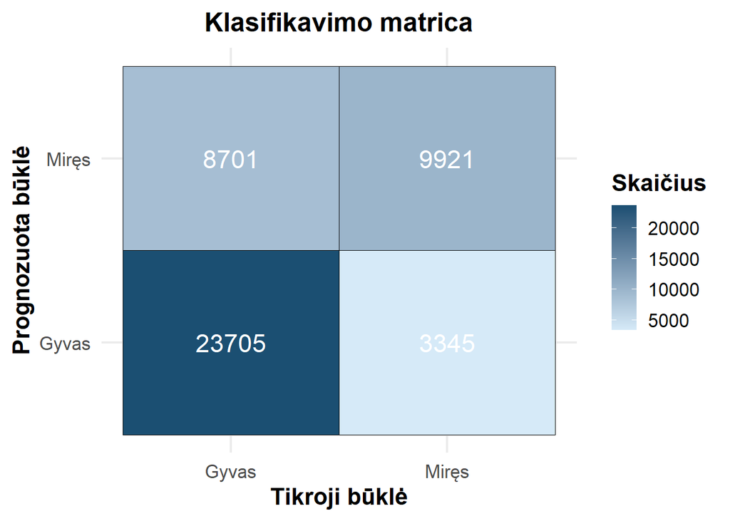

Šioje matricoje galime matyti, kiek kartų suklydome arba kiek kartų modelis suklasifikavo teisingai. Žemiau yra pateikiamos metrikos, paskaičiuotos pagal šią matricą.

Modelio veikimo rodikliai testavimo aibėje

|  | Rodiklis | Reikšmė |
| --- | --- | --- |
| Sensitivity | Jautrumas | 0.748 |
| Specificity | Specifiškumas | 0.732 |
| Precision | Tikslumas (Precision) | 0.533 |
| F1 | F1 | 0.622 |
| Accuracy | Tikslumas (Accuracy) | 0.736 |
| Kappa | Kappa | 0.428 |

Aiškinimas:

[output not shown]

Apibendrinus:

```
•   Modelis subalansuotas: tiek jautrumas, tiek specifiškumas yra vidutiniškai aukšti, todėl gali būti naudojamas ankstyvai rizikos identifikacijai.

•   Žemas tikslumas (precision) yra normalus dėl mažesnio mirčių paplitimo testavimo aibėje; todėl dalis prognozių “miręs” yra klaidingos.
```

Žmogiškai:

• Modelio kokybė kažkur tarp vidutinio ir gero modelio.

# 12 ROC ir AUC

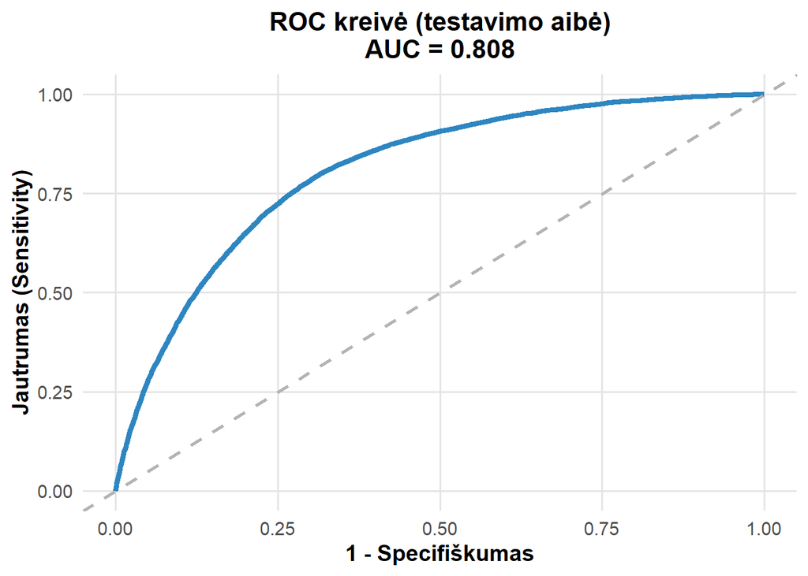

AUC 0.81 rodo, kad modelis patikimai atskiria aukštos rizikos pacientus nuo žemos rizikos pacientų.

# 13 Kintamųjų svarba

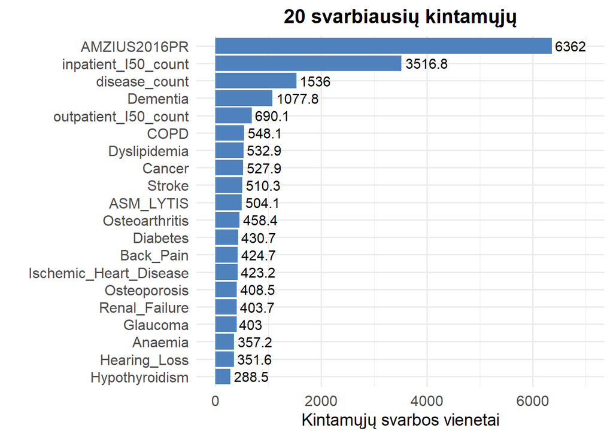

Matome, kurie kintamieji modeliui buvo svarbiausi, kad klasifikuoti reikšmes. Amžius, hospitalizacijų skaičius, ligų skaičius ir, įdomiausia, demencija yra top 4. Šiek tiek galime tai paanalizuoti.

Suskirstome pacientus į tuos kurie turi demenciją, ir tie kurie neturi. Nubraižome Kaplan-Meier grafiką.

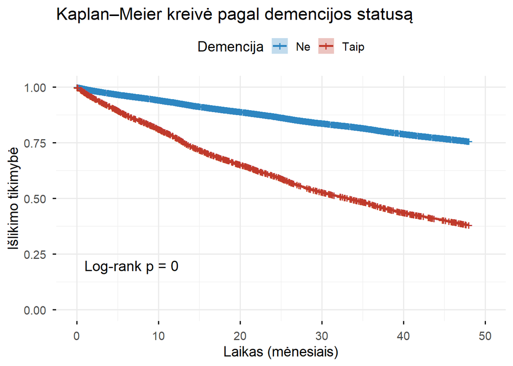

Matome, kad log-rank testo p reikšmė < 0.00001, todėl skirtumas tarp grupių yra statistiškai reikšmingas. Pacientai, turintys demenciją, turi žymiai prastesnį išgyvenamumą nei pacientai be demencijos, kaip matyti iš Kaplan–Meier kreivės. Mūsų sukurtas modelis tam taip pat pritaria. Bet nors log-rank testas parodė statistiškai reikšmingą skirtumą (p < 0.00001), taip bus visuose grafikuose. Tai tikėtina dėl didelės imties apimties, kuri suteikia testui labai didelę statistinę galią. Todėl papildomai vertinsime efekto dydį. Pakolkas galime tik sutelkti dėmesį grafiškai, ir matome, kad demencijos kreivės tikrai turį nemažą skirtumą.

# 14 Kitų kintamųjų grafikai

Kintamieji, kurie yra ne binariniai, buvo suskirstyti į grupes pagal medianas:

• „Jaunesni“ – pacientai, kurių amžius ≤ imties medianos (75 metai)

• „Vyresni“ – pacientai, kurių amžius > imties medianos (75 metai)

• „Mažai ligų“ – pacientai, kurių gretutinių ligų skaičius ≤ medianos (4 ligos)

• „Daug ligų“ – pacientai, kurių ligų skaičius > medianos (4 ligos)

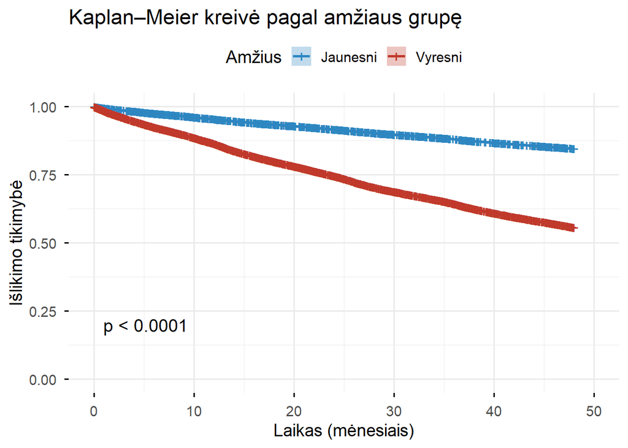

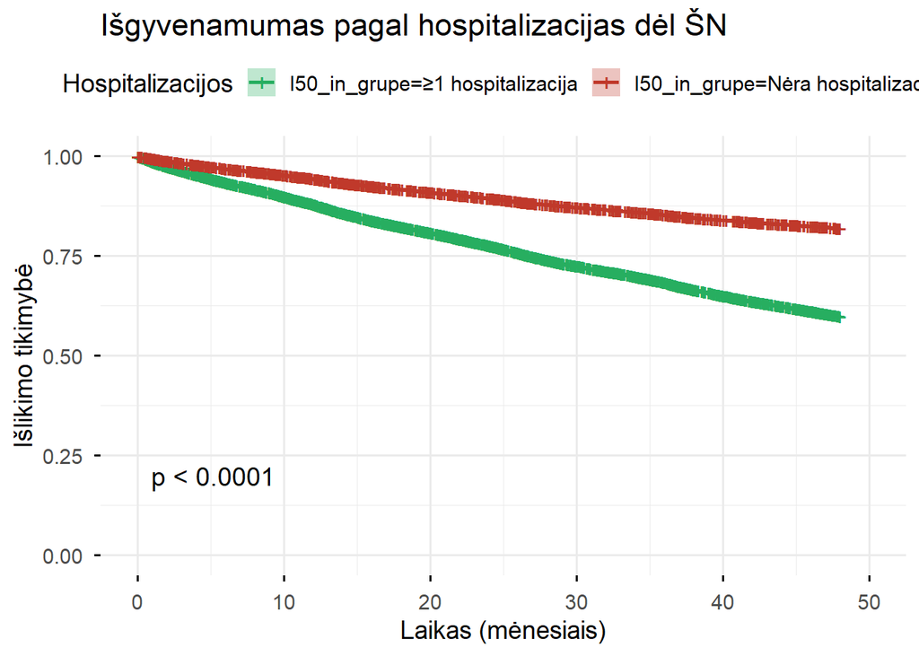

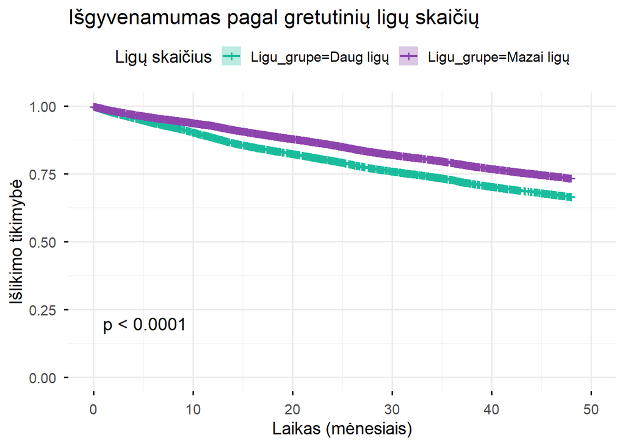

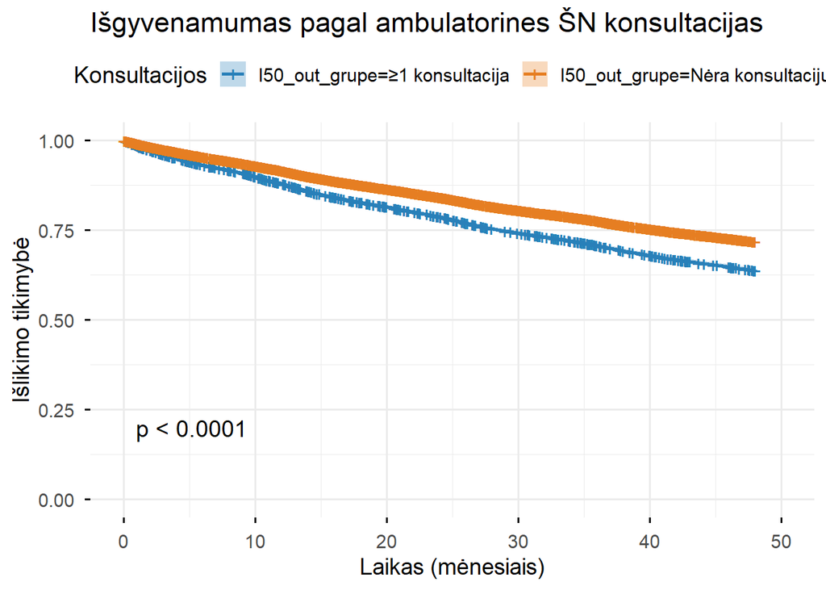

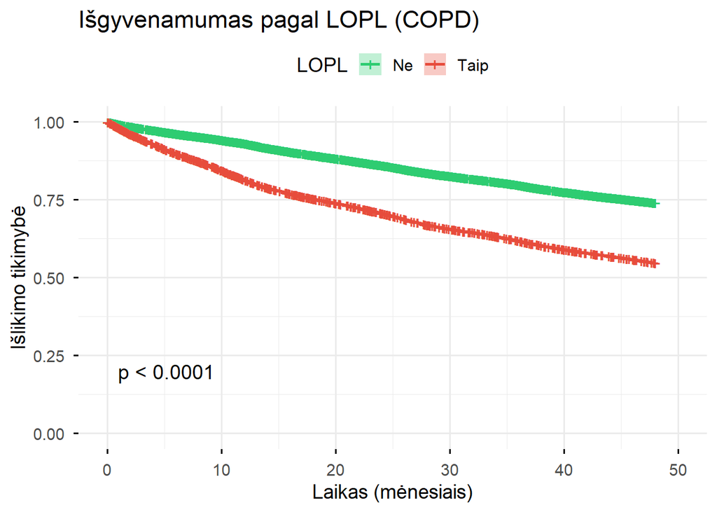

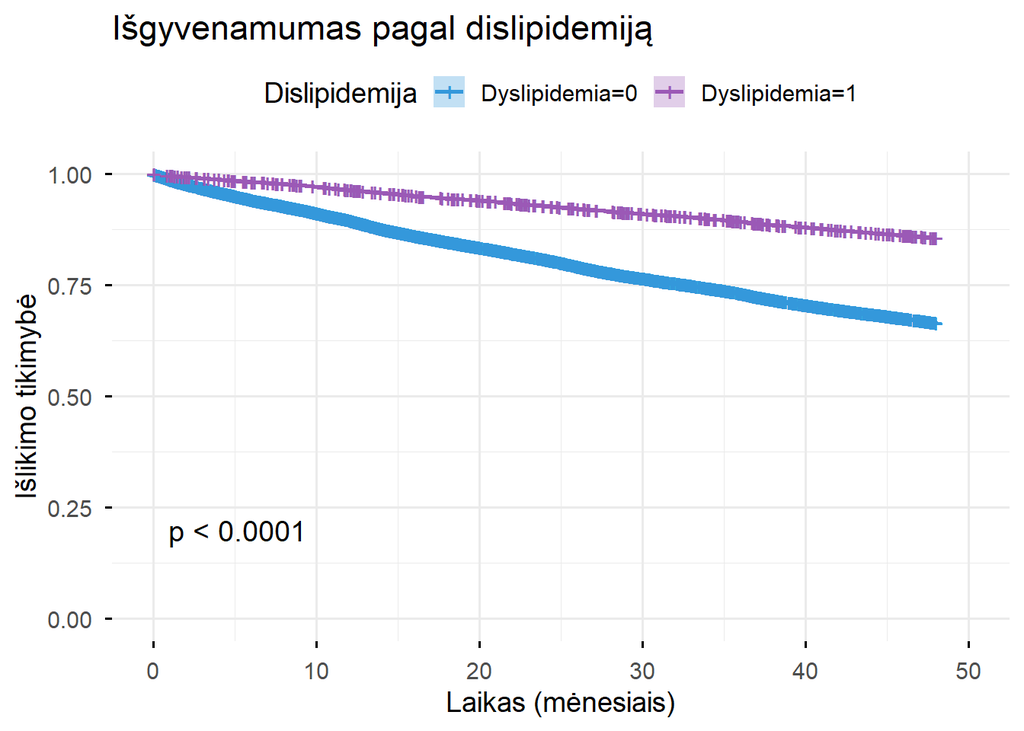

Vienmatė išgyvenamumo analizė (Cox ir log-rank testai)

| Kintamasis | Tipas | HR | CI_apatinis | CI_virsutinis | p_Cox | p_LogRank | N |
| --- | --- | --- | --- | --- | --- | --- | --- |
| Dementia | Binarinis | 3.51 | 3.44 | 3.58 | 0 | 0 | 152244 |
| COPD | Binarinis | 2.07 | 2.02 | 2.11 | 0 | 0 | 152244 |
| Dyslipidemia | Binarinis | 0.38 | 0.37 | 0.39 | 0 | 0 | 152244 |
| disease_count | Skaitinis | 1.09 | 1.09 | 1.10 | 0 | NA | 152244 |
| AMZIUS2016PR | Skaitinis | 1.08 | 1.07 | 1.08 | 0 | NA | 152244 |
| inpatient_I50_count | Skaitinis | 1.01 | 1.01 | 1.01 | 0 | NA | 152244 |
| outpatient_I50_count | Skaitinis | 1.08 | 1.08 | 1.09 | 0 | NA | 152244 |

Interpretacija

```
1.  Dementia: HR = 3.51 – pacientai su demencija turi >3,5 karto didesnę mirties riziką. Skirtumas labai reikšmingas tiek Cox, tiek log-rank testais (p < 0.001).

2.  COPD: HR = 2.07 – lėtinė obstrukcinė plaučių liga dvigubina riziką.

3.  Dyslipidemia: HR = 0.38 – mažesnė rizika. (Tikrinta kelis sykius)

4.  Skaitiniai kintamieji:

•   disease_count: kiekviena papildoma liga padidina riziką ~9 %.

•   AMZIUS2016PR: kiekvienas papildomas metai padidina riziką ~8 %.

•   inpatient_I50_count: kiekviena hospitalizacija dėl širdies nepakankamumo ~1 % padidėjimas – mažas, bet reikšmingas.

•   outpatient_I50_count: kiekviena ambulatorinė konsultacija dėl širdies nepakankamumo ~8 % padidėjimas.
```